# 8 Test de Matthews y LATCH y la lactancia materna

Autor/a

Mario Camacho

Fecha de publicación

12 junio 2026

## 8.1 Distribución de los días de lactancia materna

**Métodos**

Se describe la distribución de la duración de la lactancia materna (en días) en la cohorte de estudio. Se calculan estadísticos descriptivos (mínimo, máximo, media, mediana) y se examina la variación según el año de nacimiento y el tipo de lactancia. Se visualizan las distribuciones.

**Resultados**

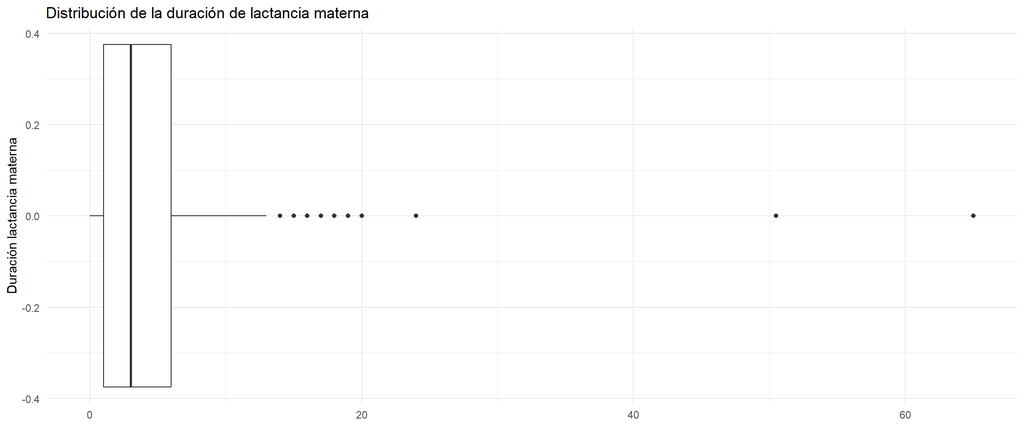

Eliminamos valores superiores a 36 meses.

Estadísticos de los días de lactancia materna

| Año de nacimiento | Nº de CIP_ANON | Nº de CIP_ANON con duración de lactancia materna desconocida | % de CIP_ANON con duración de lactancia materna desconocida | Duración de la lactancia materna mínima | Duración de la lactancia materna media | Duración de la lactancia materna mediana | Duración de la lactancia materna máxima |
| --- | --- | --- | --- | --- | --- | --- | --- |
| 2022* | 10912 | 8962 | 82.13 | 0 | 4.23 | 3 | 24 |

Estadísticos de los días de lactancia materna por tipo de lactancia

| Tipo de lactancia | Nº de CIP_ANON | Nº de CIP_ANON con duración de lactancia materna desconocida | % de CIP_ANON con duración de lactancia materna desconocida | Duración de la lactancia materna mínima | Duración de la lactancia materna media | Duración de la lactancia materna mediana | Duración de la lactancia materna máxima |
| --- | --- | --- | --- | --- | --- | --- | --- |
| Mixta | 1813 | 1253 | 69.11 | 0 | 3.28 | 2 | 20 |
| Artificial | 1746 | 1446 | 82.82 | 0 | 0.33 | 0 | 12 |
| Materna | 5161 | 4075 | 78.96 | 0 | 5.79 | 5 | 24 |
| NA | 2192 | 2188 | 99.82 | 1 | 6.75 | 7 | 12 |

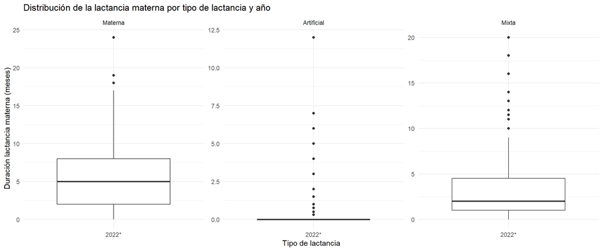

## 8.2 Efecto de la escala de valoración LATCH en la duración y éxito de la lactancia materna

**Métodos**

Se evaluó la asociación entre la escala de valoración LATCH y la duración de la lactancia materna, usando únicamente registros donde el tipo de lactancia está indicado como materna. Se presentan visualizaciones de la distribución de la duración de la lactancia según la escala LATCH, tanto en su forma numérica como categórica. Se utilizó el test no paramétrico de Kruskal-Wallis para comparar la duración de la lactancia entre los diferentes niveles de la escala LATCH. Se calculó el tamaño del efecto mediante epsilon^2. Se realizó un análisis post-hoc con test de Wilcoxon pareado para comparaciones múltiples con correción de Benjamini-Hochberg para los p-valores obtenidos en las comparaciones. En cada contraste, la hipótesis nula establece que la distribución de la duración de la lactancia materna es equivalente entre ambos grupos en términos de localización; en concreto, que no existen diferencias entre las mediana.

### 8.2.1 Lactancia materna

**Resultados**

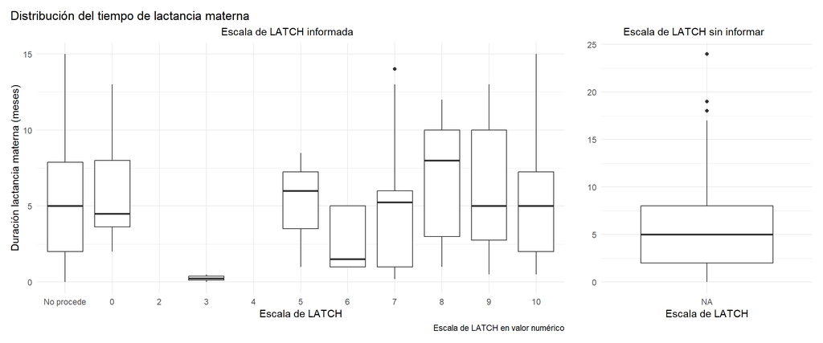

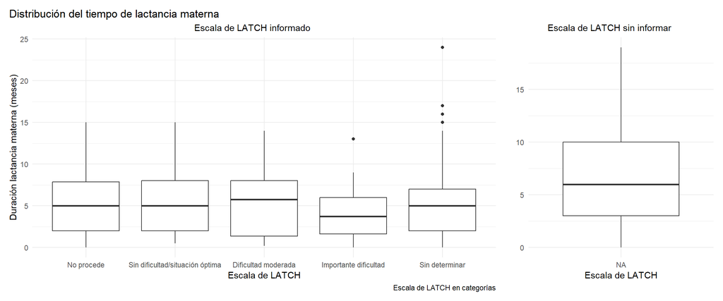

Se compara si la duración de la lactancia difiere entre categorías de la valoración de LATCH usando una prueba no paramétrica (Kruskal-Wallis), adecuada ya que no asumimos normalidad en la duración de la lactancia.

```
## No se observan diferencias estadísticamente significativas entre los niveles de la escala de valoración de LACTH (p = 0.714 ).
```

**AdvertenciaConclusiones estadísticas**

No se detectan diferencias estadísticamente significativas en la duración de la lactancia materna entre los niveles de la valoración de LATCH test de Matthew (p = 0.714), por lo que se puede asumir que todas las categorías tienen la misma distribución de la duración de la lactancia materna.

Análisis descriptivo de la duración de la lactancia materna según categorías de la valoración de LATCH (solo lactancia materna)

| **Characteristic** | **Overall** N = 3,598<sup>1</sup> | **No procede** N = 380<sup>1</sup> | **Sin dificultad/situación óptima** N = 737<sup>1</sup> | **Dificultad moderada** N = 182<sup>1</sup> | **Importante dificultad** N = 23<sup>1</sup> | **Sin determinar** N = 2,276<sup>1</sup> | **p-value**<sup>2</sup> |
| --- | --- | --- | --- | --- | --- | --- | --- |
| Duración lactancia materna (meses) | 5.0 (2.0, 7.5) | 5.0 (2.0, 8.0) | 5.0 (2.0, 8.0) | 5.8 (1.3, 8.0) | 3.8 (1.3, 7.0) | 5.0 (2.0, 7.0) |  |
| Unknown | 2,914 | 302 | 594 | 138 | 15 | 1,865 |  |

<sup>1</sup> Median (Q1, Q3)  
<sup>2</sup> NA

### 8.2.2 Lactancia materna/mixta

**Resultados**

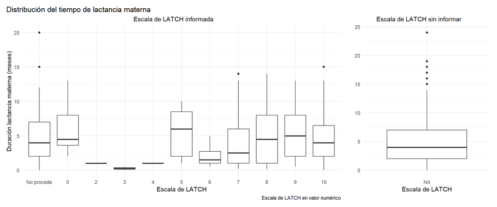

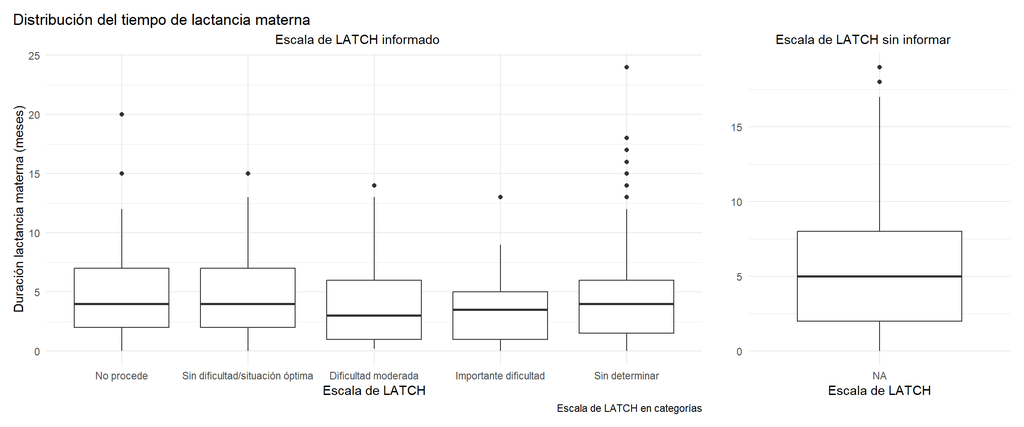

Se compara si la duración de la lactancia difiere entre categorías de la valoración de LATCH usando una prueba no paramétrica (Kruskal-Wallis), adecuada ya que no asumimos normalidad en la duración de la lactancia.

```
## No se observan diferencias estadísticamente significativas entre los niveles de la escala de valoración de LACTH (p = 0.0629 ).
```

**AdvertenciaConclusiones estadísticas**

No se detectan diferencias estadísticamente significativas en la duración de la lactancia materna entre los niveles de la valoración de LATCH test de Matthew (p = 0.0629), por lo que se puede asumir que todas las categorías tienen la misma distribución de la duración de la lactancia materna.

Análisis descriptivo de la duración de la lactancia materna según categorías de la valoración de LATCH (solo lactancia materna)

| **Characteristic** | **Overall** N = 4,877<sup>1</sup> | **No procede** N = 507<sup>1</sup> | **Sin dificultad/situación óptima** N = 912<sup>1</sup> | **Dificultad moderada** N = 291<sup>1</sup> | **Importante dificultad** N = 27<sup>1</sup> | **Sin determinar** N = 3,140<sup>1</sup> | **p-value**<sup>2</sup> |
| --- | --- | --- | --- | --- | --- | --- | --- |
| Duración lactancia materna (meses) | 4.0 (1.5, 6.0) | 4.0 (2.0, 7.0) | 4.0 (2.0, 7.0) | 3.0 (1.0, 6.0) | 3.5 (1.0, 5.0) | 4.0 (1.5, 6.0) |  |
| Unknown | 3,808 | 390 | 707 | 202 | 18 | 2,491 |  |

<sup>1</sup> Median (Q1, Q3)  
<sup>2</sup> NA

## 8.3 Efecto del test de Matthew en la duración y éxito de la lactancia materna

**Métodos**

Se evaluó la asociación entre el test de Matthew y la duración de la lactancia materna, usando únicamente registros donde el tipo de lactancia está indicado como materna. Se presentan visualizaciones de la distribución de la duración de la lactancia según el test de Matthew, tanto en su forma numérica como categórica. Se utilizó el test no paramétrico de Kruskal-Wallis para comparar la duración de la lactancia entre los diferentes niveles del test de Matthew. Se calculó el tamaño del efecto mediante epsilon^2. Se realizó un análisis post-hoc con test de Wilcoxon pareado para comparaciones múltiples con correción de Benjamini-Hochberg para los p-valores obtenidos en las comparaciones. En cada contraste, la hipótesis nula establece que la distribución de la duración de la lactancia materna es equivalente entre ambos grupos en términos de localización; en concreto, que no existen diferencias entre las mediana.

### 8.3.1 Lactancia materna

**Resultados**

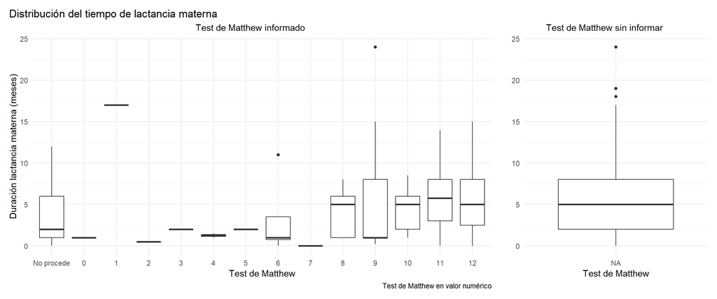

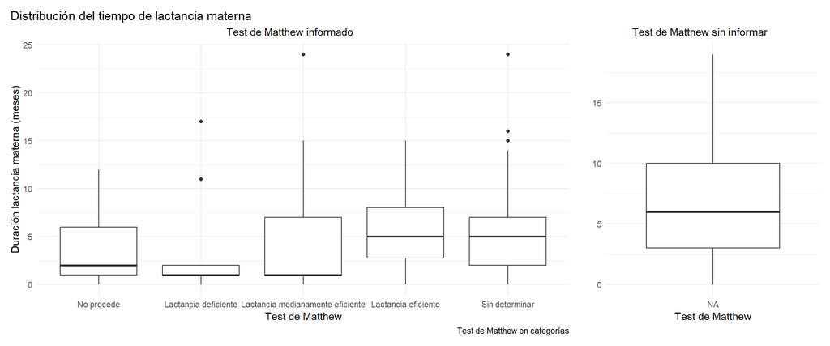

Se compara si la duración de la lactancia difiere entre categorías del test de Matthew usando una prueba no paramétrica (Kruskal-Wallis), adecuada ya que no asumimos normalidad en la duración de la lactancia.

```
## Existen diferencias estadísticamente significativas en la distribución de la duración en meses de la lactancia materna exclusiva entre los niveles del test de Matthew (p = 0.00229 ).
## Al menos un grupo difiere del resto.
##
## Tamaño de efecto (epsilon^2): 0.002 ( efecto trivial desde el punto de vista práctico)
## Comparaciones entre grupos:
## Se observaron diferencias significativas entre los siguientes grupos:
##
## - Lactancia eficiente vs Lactancia deficiente (p ajustado = 0.0361 )
## NULL
```

**AdvertenciaConclusiones estadísticas**

Se detectan diferencias estadísticamente significativas en la duración de la lactancia materna entre los niveles del test de Matthew (p = 0.0023), lo que indica que no todas las categorías presentan la misma distribución.

El tamaño del efecto es prácticamente nulo (epsilon^2 = 0.002), por lo que estas diferencias no son relevantes desde un punto de vista práctico.

En el análisis post-hoc se identifican diferencias únicamente entre los grupos “lactancia eficiente” y “lactancia deficiente”. El resto de comparaciones no resultan significativas.

Análisis descriptivo de la duración de la lactancia materna según categorías del test de Matthew (solo lactancia materna)

| **Characteristic** | **Overall** N = 3,598<sup>1</sup> | **No procede** N = 114<sup>1</sup> | **Lactancia deficiente** N = 22<sup>1</sup> | **Lactancia medianamente eficiente** N = 57<sup>1</sup> | **Lactancia eficiente** N = 1,815<sup>1</sup> | **Sin determinar** N = 1,590<sup>1</sup> | **p-value**<sup>2</sup> |
| --- | --- | --- | --- | --- | --- | --- | --- |
| Duración lactancia materna (meses) | 5.0 (2.0, 7.5) | 2.0 (1.0, 6.0) | 1.0 (1.0, 2.0) | 1.0 (1.0, 8.0) | 5.0 (2.5, 8.0) | 5.0 (2.0, 7.0) |  |
| Unknown | 2,914 | 89 | 11 | 42 | 1,460 | 1,312 |  |

<sup>1</sup> Median (Q1, Q3)  
<sup>2</sup> NA

### 8.3.2 Lactancia materna/mixta

**Resultados**

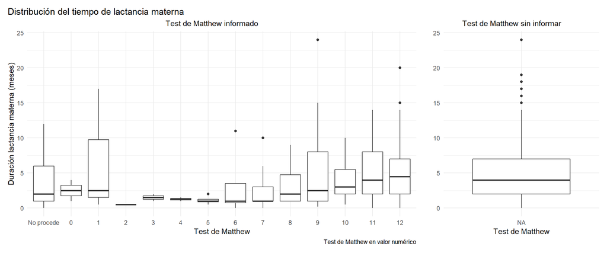

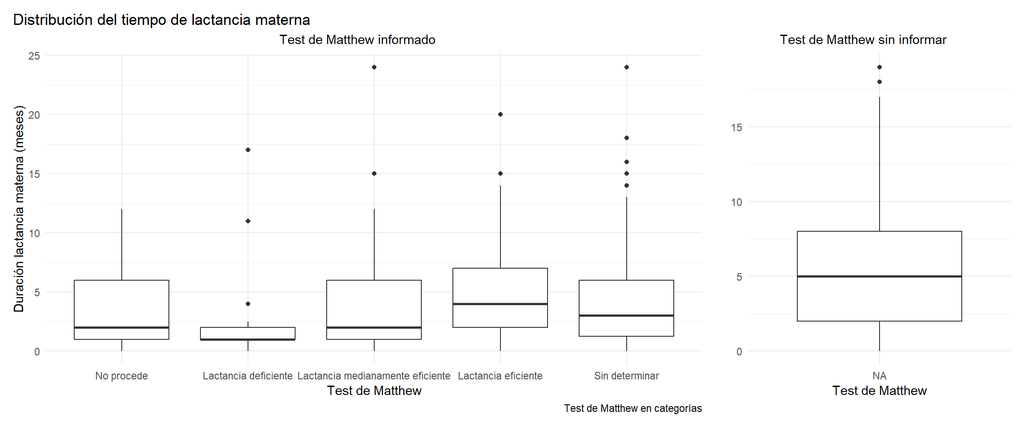

Se compara si la duración de la lactancia difiere entre categorías del test de Matthew usando una prueba no paramétrica (Kruskal-Wallis), adecuada ya que no asumimos normalidad en la duración de la lactancia.

```
## Existen diferencias estadísticamente significativas en la distribución de la duración en meses de la lactancia materna exclusiva entre los niveles del test de Matthew (p = 3.08e-07 ).
## Al menos un grupo difiere del resto.
##
## Tamaño de efecto (epsilon^2): 0.002 ( efecto trivial desde el punto de vista práctico)
## Comparaciones entre grupos:
## Se observaron diferencias significativas entre los siguientes grupos:
##
## - Lactancia eficiente vs No procede (p ajustado = 0.00399 )
## - Lactancia eficiente vs Lactancia deficiente (p ajustado = 0.00113 )
## - Sin determinar vs Lactancia deficiente (p ajustado = 0.00517 )
## - Lactancia eficiente vs Lactancia medianamente eficiente (p ajustado = 0.00517 )
## - Sin determinar vs Lactancia eficiente (p ajustado = 0.00283 )
## NULL
```

**AdvertenciaConclusiones estadísticas**

Se detectan diferencias estadísticamente significativas en la duración de la lactancia materna entre los niveles del test de Matthew (p < 0.0001), lo que indica que no todas las categorías presentan la misma distribución.

El tamaño del efecto es prácticamente nulo (epsilon^2 = 0.002), por lo que estas diferencias no son relevantes desde un punto de vista práctico.

En el análisis post-hoc se identifican diferencias entre los grupos “lactancia eficiente” y “lactancia deficiente” y entre los grupos “lactancia eficiente” y “Lactancia medianamente eficiente”. El resto de comparaciones con relevancia clínica no resultan significativas.

Análisis descriptivo de la duración de la lactancia materna según categorías del test de Matthew (solo lactancia materna)

| **Characteristic** | **Overall** N = 4,877<sup>1</sup> | **No procede** N = 162<sup>1</sup> | **Lactancia deficiente** N = 40<sup>1</sup> | **Lactancia medianamente eficiente** N = 122<sup>1</sup> | **Lactancia eficiente** N = 2,320<sup>1</sup> | **Sin determinar** N = 2,233<sup>1</sup> | **p-value**<sup>2</sup> |
| --- | --- | --- | --- | --- | --- | --- | --- |
| Duración lactancia materna (meses) | 4.0 (1.5, 6.0) | 2.0 (1.0, 6.0) | 1.0 (1.0, 2.0) | 2.0 (1.0, 6.0) | 4.0 (2.0, 7.0) | 3.0 (1.0, 6.0) |  |
| Unknown | 3,808 | 117 | 22 | 82 | 1,809 | 1,778 |  |

<sup>1</sup> Median (Q1, Q3)  
<sup>2</sup> NA